# Offensive Language Analysis

A f’ing fun introduction to tidytext analysis with geniusR

My recent package [`geniusR`](https://github.com/josiahparry.geniusR) was created with the idea of a tidytext analysis of song lyrics in mind. I now wish to introduce you to the concepts and application of tidytext analysis through the use of `geniusR`. If you would like an introduction to `geniusR` please read my [Introduction to geniusR](https://medium.com/@JosiahParry/introducing-geniusr-b0177ce7b4d7). Additionally, I recommend that you give [Text Mining in R: A Tidy Approach](https://www.tidytextmining.com/) by [Julia Silge](https://twitter.com/juliasilge) and [David Robinson](https://twitter.com/drob) a read.

Initially I wanted to perform an exploratory text analysis of Kendrick Lamar’s recent album **DAMN.** (2017) and compare it to his older album [**Section.80**](https://en.wikipedia.org/wiki/Section.80) (2011). During my first analysis I could not help but notice that a lot of the most common words are swear words. For this reason, I want to embark in a small exploratory analysis of **profanity** and **offensive language** in Kendrick Lamar’s music.

With that in mind, please be aware that this analysis will produce plots with multiple expletives and words that may be considered **NSFW** (not safe for work). Though, if you are familiar with Kendrick and his contemporaries you may be more accustomed to the language.

# Song Lyrics with [`geniusR`](https://github.com/josiahparry/geniusR)

To begin any analysis, we need to prep our working environment. We will be loading three packages to be used throughout this analysis.

#### Setting up your workspace

```r
library(geniusR)
library(tidytext)
library(tidyverse)
```

If you do not have these packages installed run the below code:

```r
install.packages("devtools")
devtools::install_github("josiahparry/geniusR")
install.packages("tidyverse")
install.packages("tidytext")
```

The first task is simple. It is time to get the lyrics. We could go the old school way of downloading the lyrics one album at a time and then binding the rows, but we have the power of [`purrr`](http://purrr.tidyverse.org/) at our fingertips.

We will make a [`tibble`](http://tibble.tidyverse.org/) (an improvement upon the data frame) with two columns: `artist` and `album`.

| artist | album |
| --- | --- |
| Kendrick Lamar | Section 80 |
| Kendrick Lamar | DAMN. |

This tibble will be helpful in being able to iteratively download each album. We can now feed these columns to the `genius_album()` function by using `purrr::map2()`. `map2()` allows you to *“iterate over multiple arguments”* at the same time and apply a function. We will use `map2()` within a `mutate()` call to create a nested tibble column. This means that the values of our `tracks` column will be another tibble.

| artist | album | tracks |
| --- | --- | --- |
| Kendrick Lamar | Section 80 |  |
| Kendrick Lamar | DAMN. |  |

We can now access the tracklist by unnesting the `tracks` column. But the `tracks` column also contains another nested tibble containing the actual lyrics. Let us first unnest `tracks` and view the song lists.

| title | album | artist | track_n | lyrics |
| --- | --- | --- | --- | --- |
| Fuck Your Ethnicity | Section 80 | Kendrick Lamar | 1 |  |
| Hol' Up | Section 80 | Kendrick Lamar | 2 |  |
| A.D.H.D | Section 80 | Kendrick Lamar | 3 |  |
| No Makeup (Her Vice) (Ft. Colin Munroe) | Section 80 | Kendrick Lamar | 4 |  |
| Tammy's Song (Her Evils) | Section 80 | Kendrick Lamar | 5 |  |
| Chapter Six | Section 80 | Kendrick Lamar | 6 |  |
| Ronald Reagan Era (His Evils) (Ft. Ash Riser & RZA) | Section 80 | Kendrick Lamar | 7 |  |
| Poe Man's Dreams (His Vice) (Ft. GLC) | Section 80 | Kendrick Lamar | 8 |  |
| The Spiteful Chant (Ft. ScHoolboy Q) | Section 80 | Kendrick Lamar | 9 |  |
| Chapter Ten | Section 80 | Kendrick Lamar | 10 |  |

[output cut: 20 more lines]

You can tell by the first song title on **Section 80**, *Fuck Your Ethnicity* that Kendrick doesn’t shy away from *“offensive language”*.

If we unnest one step further, we can access all of the lyrics and start prepping for a tidytext analysis.

| artist | album | title | track_n | text | line |
| --- | --- | --- | --- | --- | --- |
| Kendrick Lamar | Section 80 | Fuck Your Ethnicity | 1 | Gather around. I'm glad everybody came out tonight. As we stand on our neighborhood corner, know that this fire that's burning represents the passion you have. Listen, Keisha, Tammy, come up front. I … | 1 |
| Kendrick Lamar | Section 80 | Fuck Your Ethnicity | 1 | Now everybody, throw your hands up high | 2 |
| Kendrick Lamar | Section 80 | Fuck Your Ethnicity | 1 | If you don't give a fuck, throw your hands up high | 3 |
| Kendrick Lamar | Section 80 | Fuck Your Ethnicity | 1 | Now I don't give a fuck if you | 4 |
| Kendrick Lamar | Section 80 | Fuck Your Ethnicity | 1 | Black, White, Asian, Hispanic, goddammit | 5 |
| Kendrick Lamar | Section 80 | Fuck Your Ethnicity | 1 | That don't mean shit to me | 6 |

The resultant tibble, `lyrics` has 6 variables. Let’s get to know them before we dive into the tidytext analysis.

- `artist`: I bet you figured that one out
- `album`: The album title, but you knew that
- `title`: The song title
- `track_n`: The track number on the album. This is the position on the tracklist.
- `text`: The line as written on [Genius](https://genius.com)
- `line`: The line number associated with `text`

# Tidytext principles

The `tidy` approach was formally introduced in [Hadley Wickham](https://twitter.com/hadleywickham)’s 2014 paper, [*Tidy Data*](https://doi.org/10.18637/jss.v059.i10). As the progenitors of the `tidytext` approach, I’d like to steal from Julia Silge’s and David Robinson’s book [Text Mining with R](https://www.tidytextmining.com/).

> *We thus define the tidy text format as being a table with one-token-per-row. A token is a meaningful unit of text, such as a word, that we are interested in using for analysis, and tokenization is the process of splitting text into tokens.*

Okay, but what the does this mean? It means that we’re going to split each line into their individual words and that each word will be it’s own row.

Let’s get into the thick of it and start using some functions from `tidytext`. The first we will use is `unnest_tokens()`. This function will turn our `text` column into a tidy data frame format that fits the above description. After piping (the `%>%` thing) our data to the `unnest_tokens()` function, we need to supply it with 2 arguments.

- `output`: the new column name, unquoted
- `input` : the column which will be transformed, unquoted

### Tokenizing

Since we are using the default arguments, it will split the text into one word units, also called **unigrams**. This comes from *n-grams* where `n` is the number of bits, and the `gram` is the unit. But don’t trip on that right now.

| artist | album | title | track_n | line | word |
| --- | --- | --- | --- | --- | --- |
| Kendrick Lamar | Section 80 | Fuck Your Ethnicity | 1 | 1 | gather |
| Kendrick Lamar | Section 80 | Fuck Your Ethnicity | 1 | 1 | around |
| Kendrick Lamar | Section 80 | Fuck Your Ethnicity | 1 | 1 | i'm |
| Kendrick Lamar | Section 80 | Fuck Your Ethnicity | 1 | 1 | glad |
| Kendrick Lamar | Section 80 | Fuck Your Ethnicity | 1 | 1 | everybody |
| Kendrick Lamar | Section 80 | Fuck Your Ethnicity | 1 | 1 | came |
| Kendrick Lamar | Section 80 | Fuck Your Ethnicity | 1 | 1 | out |
| Kendrick Lamar | Section 80 | Fuck Your Ethnicity | 1 | 1 | tonight |
| Kendrick Lamar | Section 80 | Fuck Your Ethnicity | 1 | 1 | as |
| Kendrick Lamar | Section 80 | Fuck Your Ethnicity | 1 | 1 | we |

[output cut: 990 more lines]

Now since this is an analysis of only profanities, we have to be rid of all other less offensive words. We can do this by loading the [`profanities`](https://www.cs.cmu.edu/~biglou/resources/bad-words.txt) data set that comes with `geniusR` and joining the datasets.

The `profanities` data set was acquired from [Luis Von Ahn’s](https://en.wikipedia.org/wiki/Luis_von_Ahn) (founder of reCAPTCHA & Duolingo) research group at Carnegie Mellon University.

The description of the data set is:

> *“A list of 1,300+ English terms that could be found offensive. The list contains some words that many people won’t find offensive, but it’s a good start for anybody wanting to block offensive or profane terms on their Site.”*

### Isolating words using a join

In order to isolate all of the offensive words, we can preform an `inner_join()`. An *inner join* is a type of table join (that is the combining of one table to the other based on a shared feature). To steal from the [`dplyr`](https://dplyr.tidyverse.org) documentation, given two tables, `x` & `y`, an inner join “return[s] all rows from x where there are matching values in y, and all columns from x and y. If there are multiple matches between x and y, all combination of the matches are returned.”

| artist | album | title | track_n | line | word |
| --- | --- | --- | --- | --- | --- |
| Kendrick Lamar | Section 80 | Fuck Your Ethnicity | 1 | 1 | fire |
| Kendrick Lamar | Section 80 | Fuck Your Ethnicity | 1 | 1 | color |
| Kendrick Lamar | Section 80 | Fuck Your Ethnicity | 1 | 1 | fuck |
| Kendrick Lamar | Section 80 | Fuck Your Ethnicity | 1 | 1 | shit |
| Kendrick Lamar | Section 80 | Fuck Your Ethnicity | 1 | 3 | fuck |
| Kendrick Lamar | Section 80 | Fuck Your Ethnicity | 1 | 4 | fuck |
| Kendrick Lamar | Section 80 | Fuck Your Ethnicity | 1 | 5 | black |
| Kendrick Lamar | Section 80 | Fuck Your Ethnicity | 1 | 5 | asian |
| Kendrick Lamar | Section 80 | Fuck Your Ethnicity | 1 | 5 | goddammit |
| Kendrick Lamar | Section 80 | Fuck Your Ethnicity | 1 | 6 | shit |

[output cut: 919 more lines]

Now that we have isolated only offensive words within each album, we can begin exploring these data.

# Word Frequency

An initial exploratory analysis of text often involves looking at word frequency. Word frequency can give insight into what sort of language might be prominent. This portion of an analysis often leads one to identifying things of interest.

A simple first question to ask is “which has more”? This can be explored by aggregating by the album and summing the number of occurences each “offensive” word has.

### Which Album Is More Profane?

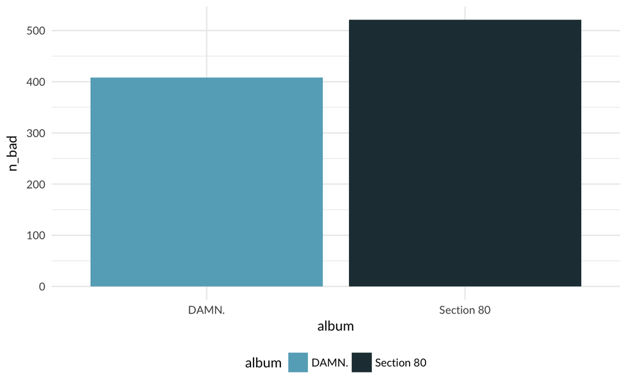

It is important to note that raw counts can be misleading sometimes. What if one album twice as many words as the other? That would invariably lead to a larger count of profanities in one than the other. The proportion is also known as the `relative frequency` which is in this case `# profanities / total # of words`.

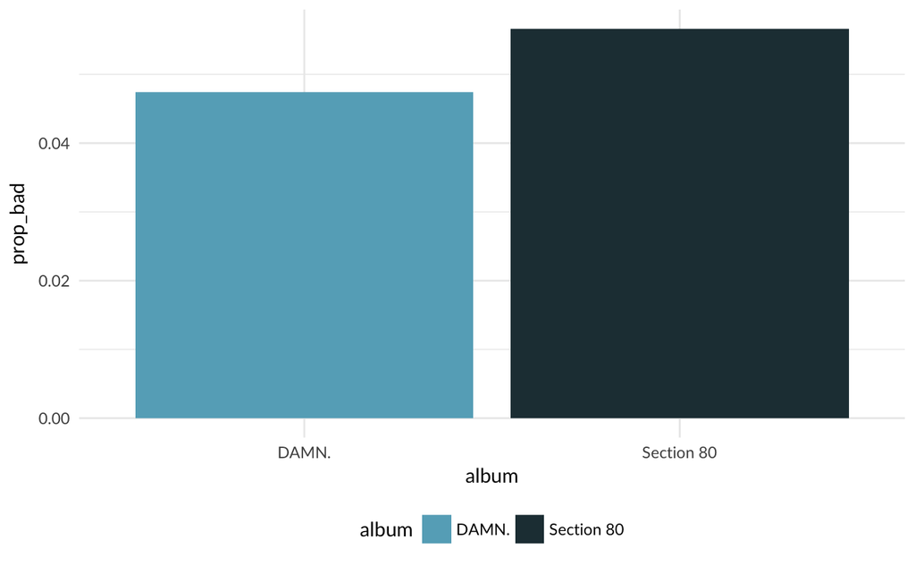

It looks like there has been a reduction in the amount of offensive words used between these two albums.

### Most Common Offensive Words by Album

From this point, we can dive even deeper by isolating the most frequent words per album. This can be done with a lot of helpful functions from `dplyr`.

We will select the top 10 most frequent words in each album by group the `bad_count` tibble by the `album` and using the `top_n()` function. We will then pipe the resultant tibble into a nice plot.

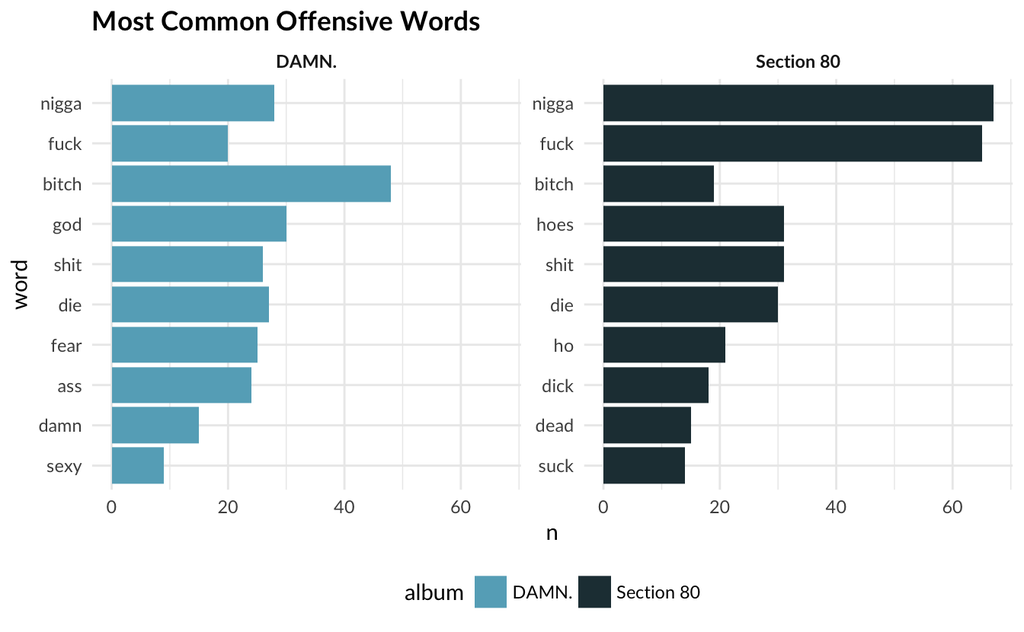

### How does offensive language progress through the each album?

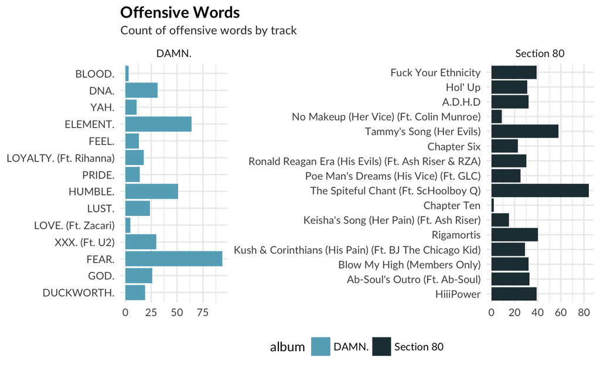

From this we can see that the most offensive songs in **DAMN.** and **Section.80** are “FEAR.”, and “The Spiteful Chant” respectively.

## Bigrams

Moving past the unigram, we can evaluate word pairings. This will require a bit more wrangling than the unigrams. We will utilize the `tidyr::separate()` and `tidyr::unite()` functions to help select only offensive words.

We will do this in a few steps that we will chain together. Run each step independently and print it to the console to get an understand of what is happening.

What’s happening:

- the plain lyrics (the `text` column) is fed using the pipe, `%>%` into the `unnest_tokens()` which then separates the text into every word pair, or bigram.
  - Note: the prefix *bi* means `2`, and *gram* is the text unit (word). Thus *bigram* can be understood as word pairs in this setting.
- Those word pairs are then being separated into their constituent parts. This way we can identify which bigram has an offensive word in it.
- We then filter to identify bigrams with an offensive word in it using `dplyr::filter()`.
  - This filter statement in plain language says:
  - > *“If `word1` is in `profanities` give me that row. OR (the single bar, or pipe depending on your background, `|`) `word2` is in`profanities`, give me that row.”*

| artist | album | title | track_n | line | word1 | word2 |
| --- | --- | --- | --- | --- | --- | --- |
| Kendrick Lamar | DAMN. | BLOOD. | 1 | 4 | or | die |
| Kendrick Lamar | DAMN. | BLOOD. | 1 | 5 | a | blind |
| Kendrick Lamar | DAMN. | BLOOD. | 1 | 5 | blind | woman |
| Kendrick Lamar | DAMN. | BLOOD. | 1 | 9 | wanna | kill |
| Kendrick Lamar | DAMN. | BLOOD. | 1 | 9 | kill | us |
| Kendrick Lamar | DAMN. | DNA. | 2 | 3 | cocaine | quarter |
| Kendrick Lamar | DAMN. | DNA. | 2 | 7 | new | weapon |
| Kendrick Lamar | DAMN. | DNA. | 2 | 8 | your | fucking |
| Kendrick Lamar | DAMN. | DNA. | 2 | 8 | fucking | head |
| Kendrick Lamar | DAMN. | DNA. | 2 | 11 | just | kill |

[output cut: 990 more lines]

Now that we have all of the rows which contain an offensive word, we can evaluate most common word pairings. We can then identify, for example, the word that most follows *“fuck”*.

[output not shown]

[output cut: 759 more lines]

We can plot words pairwise.

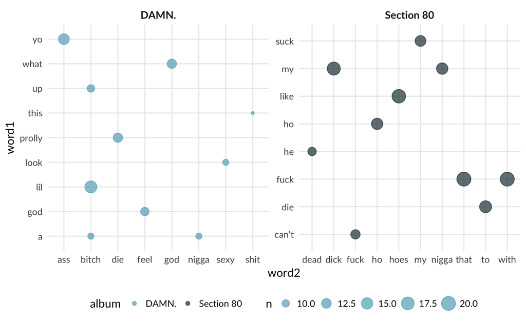

We could also visualize this a litle differently by looking at the count of bigrams using a fun adaptation of the bar chart called the *lollipop* chart.

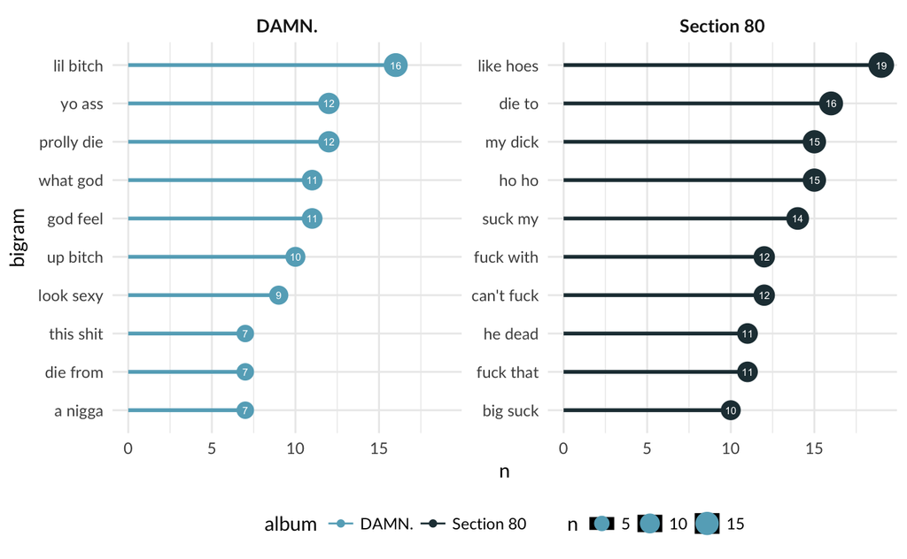

Looking at Section 80, we can tell that “fuck” appears most frequently with “that” and “with”. If you are familiar with the song *“A.D.H.D”* you might be able to guess that the number of *“fuck that”* ocurances are probably from that song. Let’s check that! Let’s do this by uniting the `word1` and `word2` columns back into a single string that contains both words. We will do this the `tidyr::unite()` funciton.

| album | bigram | n |
| --- | --- | --- |
| Section 80 | fuck that | 20 |
| Section 80 | fuck with | 20 |
| Section 80 | like hoes | 19 |
| Section 80 | my dick | 18 |
| DAMN. | lil bitch | 16 |
| Section 80 | die to | 16 |
| Section 80 | ho ho | 15 |
| Section 80 | my nigga | 15 |
| DAMN. | yo ass | 14 |
| Section 80 | suck my | 14 |

[output cut: 793 more lines]

Now we can look at just the song *“A.D.H.D”* by filtering and counting.

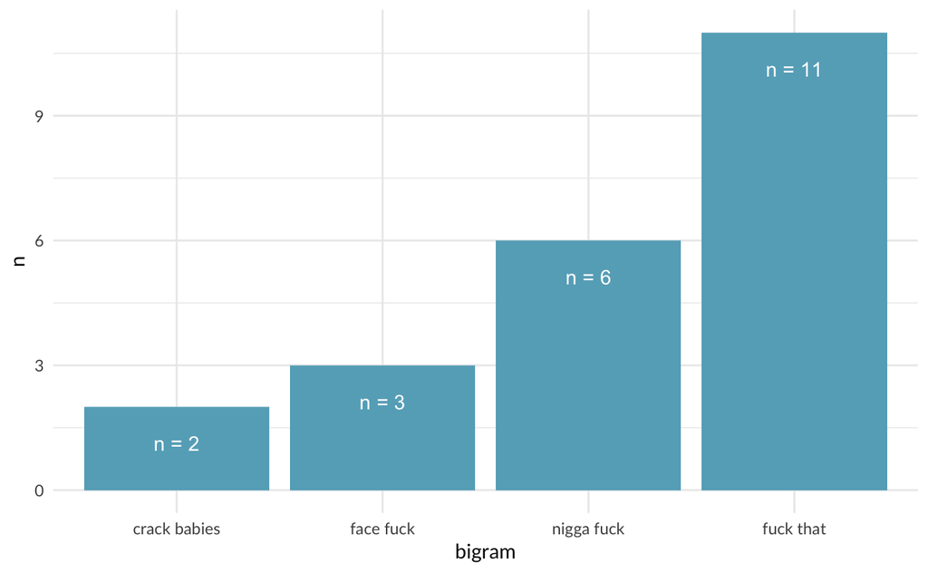

From this we see that the phrase *“fuck that”* occurs 11 times alone in *“A.D.H.D”*.

# Document Level Frequency

There a number of statistics we can use to measure occurances of a word or a phrase and it’s relationship to other documents. In this case, we can treat each album as a unique document and compare between these.

The tidytext package comes with a function called `bind_tf_idf()`. In your head you should hear `bind term-frequency inverse-document-frequency`. Before we can get into what this is, we need to be able to manipulate our `bigrams` tibble into a format that can be used for this function. The data frame that we feed the function needs to be in a tidytext format. This means that there will be one row per token (bigram) per document with a count of how many times that token occurs.

Thus the data frame will have three columns:

- `album` : the document
- `bigram`: the token
- `n`: the count

We will make our bigrams tibble into this structure by counting the bigrams by album (what we are considering a document).

| album | bigram | n |
| --- | --- | --- |
| DAMN. | a asshole | 1 |
| DAMN. | a bitch | 9 |
| DAMN. | a blind | 1 |
| DAMN. | a color | 1 |
| DAMN. | a damn | 2 |
| DAMN. | a fuck | 4 |

### Making a tf-idf data frame

What the is `tf_idf`? Again, it stands for `term-frequency inverse-document-frequency`. The `bind_tf_idf()` function will create a tibble with 6 columns. It will maintain the three that we created (`document`,`token`, `n`) but will append 3 other columns to it. These are:

If we feed the `bigram_tidy` to `bind_tf_idf()` function, the resultant table will have all of the above statistics. We can take the `tf-idf` score and try identify word pairings that are the most unique to each album.

As a note, be aware that we are working with a very small corpus of text. This means that the statistics that we are generating are not very informative.

| album | bigram | n | tf | idf | tf_idf |
| --- | --- | --- | --- | --- | --- |
| Section 80 | fuck that | 20 | 0.02463054 | 0.6931472 | 0.01707259 |
| Section 80 | fuck with | 20 | 0.02463054 | 0.0000000 | 0.00000000 |
| Section 80 | like hoes | 19 | 0.02339901 | 0.6931472 | 0.01621896 |
| Section 80 | my dick | 18 | 0.02216749 | 0.0000000 | 0.00000000 |
| DAMN. | lil bitch | 16 | 0.02435312 | 0.6931472 | 0.01688030 |
| Section 80 | die to | 16 | 0.01970443 | 0.6931472 | 0.01365807 |

#### Plot tf-idf score by album

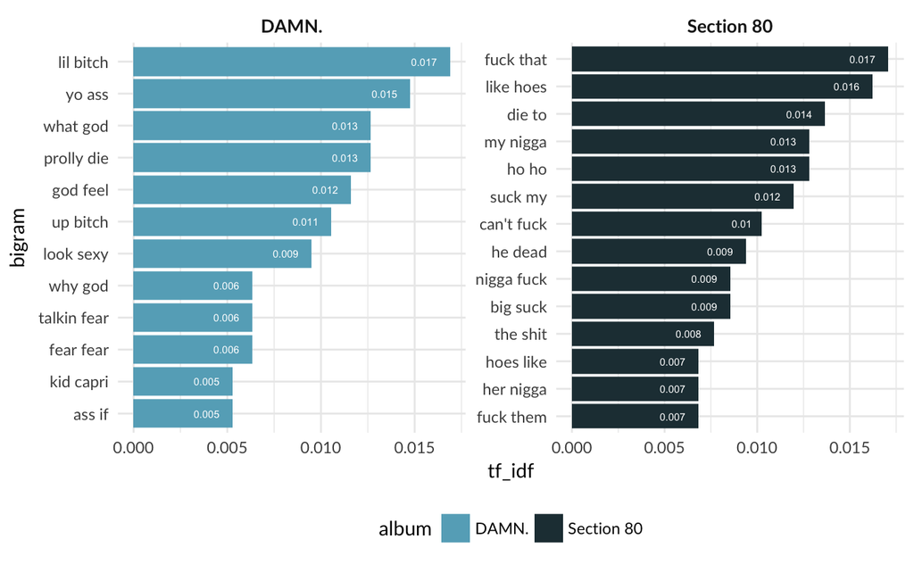

This plot shows us that the phrases *“lil bitch”* and *“fuck that”* are the most unique to each album with similar scores of `0.017`.

### Wrapping Up

I hope that this has helped you in being able to grasp tidytext principles in an enjoyable manner. I also recommend that you try adapting the lessons learned in this to your favorite albums or songs. The same principles explained here apply to topics other than offensive language.

Future writings will explore topic modelling of song lyrics in a tidy format.

If you have any questions please feel free to reach out to me on [twitter](https://twitter.com/JosiahParry). I try to be as responsive as possible.